# Bond Fair Value Analysis

Lawrence May

2024-06-05

In this project I am using price data on Floating Rate Notes to build a model the fair value of primary bond issues.I start by doing some exploratory data analysis to get a better understanding of the data set, clean the dataset and remove outliers and do some feature engineering to make features more useful. I then fit a couple of different models, from linear regression to regularised regression and some tree based models. I will demonstrate that an XGboost regressor best fits the dataset, with a RMSE of around 27bps.

### Reading in the data

```r
suppressMessages(library(tidyverse))
suppressMessages(library(ggplot2))
suppressMessages(library(dplyr))
suppressMessages(library(caret))
suppressMessages(library(glmnet))
suppressMessages(library(xgboost))

historic_data <- read_csv("historic_data.csv", show_col_types = FALSE) %>% select(-extract_time) #dropping extract_time, irrelevant
snapshot_data <- read_csv("snapshot_data.csv", show_col_types = FALSE) %>% select(-c(extract_time, nxt_call_dt)) #also dropping nxt_call_dt since i merge with static_data and this already has the column
static_data<- read_csv("static_data.csv", show_col_types = FALSE) %>% select(-extract_time)

print(paste("Num. obs. Snapshot data:", n_distinct(snapshot_data$id)))
```

```
## [1] "Num. obs. Snapshot data: 616"
```

```r
print(paste("Num. obs. Historic data:", n_distinct(historic_data$id)))
```

```
## [1] "Num. obs. Historic data: 528"
```

```r
print(paste("Num. obs. Static data:", n_distinct(static_data$id)))
```

```
## [1] "Num. obs. Static data: 616"
```

Looks like historic data is missing some ISINs. Given that flt_spread and disc_mrgn_mid are some of the most important variables, I will quickly check their quality/ completeness.

### EDA

```r
sum(is.na(static_data$flt_spread)) #counting NAs
```

```
## [1] 0
```

```r
sum(is.na(snapshot_data$disc_mrgn_mid)) # 256 isins missing current disc_mrgn_mid
```

```
## [1] 256
```

To get more information on these NA’s, I will merge static data and snapshot data

```r
static_data <- merge(static_data,snapshot_data,by="id")
static_data[order(static_data$final_maturity),] %>% head()
```

```
##                id      id_isin                   issuer    security_name
## 523 JV677267 Corp AU3FN0030037 ROYAL BANK OF CANADA/SYD    RY 0 01/20/17
## 2   AF269187 Corp AU3FN0028213    TORONTO-DOMINION BANK    TD 0 01/23/17
## 303 EI963427 Corp AU3FN0014866   COMMONWEALTH BANK AUST CBAAU 0 01/25/17
## 369 EJ889385 Corp AU3FN0020855   CANADIAN IMPERIAL BANK    CM 0 01/25/17
## 304 EI998858 Corp AU3FN0014874     WESTPAC BANKING CORP  WSTP 0 02/06/17
## 338 EJ535546 Corp XS0884604645        KOMMUNALBANKEN AS   KBN 0 02/07/17
##     flt_spread final_maturity first_call_dt_issuance   issue_dt amt_issued
## 523         45     2017-01-20                   <NA> 2016-01-22   6.60e+08
## 2           48     2017-01-23                   <NA> 2015-07-23   3.50e+08
## 303        175     2017-01-25                   <NA> 2012-01-25   1.50e+09
## 369         52     2017-01-25                   <NA> 2013-10-25   5.00e+08
## 304        165     2017-02-06                   <NA> 2012-02-06   1.90e+09
## 338         33     2017-02-07                   <NA> 2013-02-07   4.25e+08
##     cntry_issue_iso cntry_of_domicile is_kangaroo is_subordinated payment_rank
```

[output cut: 41 more lines]

It appears that these NAs occur due to some of the bonds already having matured. Since this means that we don’t have any information about our response variable, disc_mrgn_mid with these issues I will remove them from the data set for now. At a later stage, I might look at whether we use the information in historic_data to get a value for disc_mrgn_mid for them before they matured. This would of course not be ideal, as these likely depend on present market conditions which may have changed since they have matured. However, comparing historic disc_mrgn_mid with current ones for issues that haven’t yet matured would give an indication on whether this approach would be feasible.

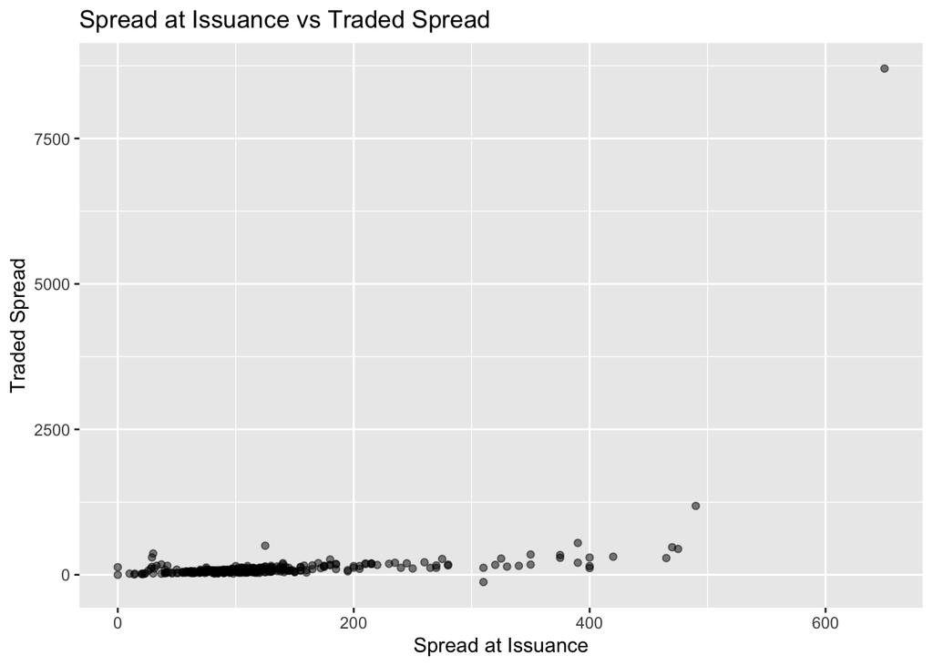

```r
#removing all NA values for disc_mrgn_mid. This should remove all already matured issues
static_data <- static_data[complete.cases(static_data$disc_mrgn_mid), ]
# Plot spread at issuance vs current mkt spread
ggplot(static_data, aes(x = flt_spread, y = disc_mrgn_mid)) +
  geom_point(alpha = 0.5) +
  labs(title = "Spread at Issuance vs Traded Spread",
       x = "Spread at Issuance",
       y = "Traded Spread")
```

We notice a few outliers here, need to investigate what is going on here/ check if faulty data.

```r
static_data[order(-static_data$disc_mrgn_mid),] %>% head()
```

```
##                id      id_isin                  issuer     security_name
## 545 QJ138847 Corp AU3FN0029096             AXSESSTODAY AXSEST 0 10/09/21
## 174 AT518665 Corp AU0000017717             AXSESSTODAY AXSEST 0 07/20/23
## 277 EF828225 Corp NZFCND0004S9   NUFARM FINANCE NZ LTD      NUFAU 0 PERP
## 262 EC170804 Corp AU0000NABHA7 NATIONAL AUSTRALIA BANK        NAB 0 PERP
## 615 ZS915909 Corp AU3FN0048013  BYRNS SMITH UNIT TRUST BYSMTR 0 06/03/24
## 35  AM961998 Corp AU0000VLWHA3         VILLA WORLD LTD  VLWAU 0 04/21/22
##     flt_spread final_maturity first_call_dt_issuance   issue_dt amt_issued
## 545        650     2021-10-09             2017-10-09 2015-10-09   5.00e+07
## 174        490     2023-07-20                   <NA> 2018-07-20   5.50e+07
## 277        390           <NA>             2011-11-24 2006-11-24   2.51e+08
## 262        125           <NA>             2004-06-29 1999-06-29   2.00e+09
## 615        470     2024-06-03             2021-06-03 2019-06-03   6.00e+07
## 35         475     2022-04-21                   <NA> 2017-04-21   5.00e+07
##     cntry_issue_iso cntry_of_domicile is_kangaroo is_subordinated
```

[output cut: 48 more lines]

Both of these outliers trading at a 87% and 12% margins, compared to around 5% and below were the nearest other issues are trading. This clearly does not look right. Both were issued by “AXSESSTODAY” which, according to a quick Google search, has been put into administration/ would have been at default risk at the time. Given that Coolabah’s investment strategy generally focuses on high-quality issues, I will exclude these two data points as they would likely skew the model.

```r
static_data[order(static_data$disc_mrgn_mid),] %>% head()
```

```
##                id      id_isin                   issuer    security_name
## 315 EJ217462 Corp AU0000TTSHA8          TATTS GROUP LTD TTSAU 0 07/05/19
## 477 EK838801 Corp AU3SG0001449 NEW S WALES TREASURY CRP NSWTC 0 10/08/20
## 22  AM581863 Corp AU3SG0001662  WESTERN AUST TREAS CORP  WATC 0 03/03/20
## 375 EJ932079 Corp AU3SG0001266  WESTERN AUST TREAS CORP  WATC 0 11/19/19
## 385 EK080188 Corp AU3SG0001308 SOUTH AUST GOVT FIN AUTH  SAFA 0 02/24/20
## 205 AU477108 Corp AU3FN0044947     WESTPAC BANKING CORP  WSTP 0 09/13/19
##     flt_spread final_maturity first_call_dt_issuance   issue_dt amt_issued
## 315        310     2019-07-05                   <NA> 2012-06-29  194664200
## 477          0     2020-10-08                   <NA> 2015-04-08 1900000000
## 22          14     2020-03-03                   <NA> 2017-03-03 1095000000
## 375         21     2019-11-19                   <NA> 2013-11-19 2099000000
## 385         20     2020-02-24                   <NA> 2014-02-24 2000000000
## 205         37     2019-09-13                   <NA> 2018-09-14  550000000
##     cntry_issue_iso cntry_of_domicile is_kangaroo is_subordinated payment_rank
```

[output cut: 41 more lines]

Another strange looking data point is isin “AU0000TTSHA8” which is trading at 125bps below the risk free benchmark rate, which seems odd for a corporate bond. This could either be due to the maturity date being only days away and this somehow messing with the calculation, or a data error. Either way, it does not look right and I will remove it so it doesn’t distort the model.

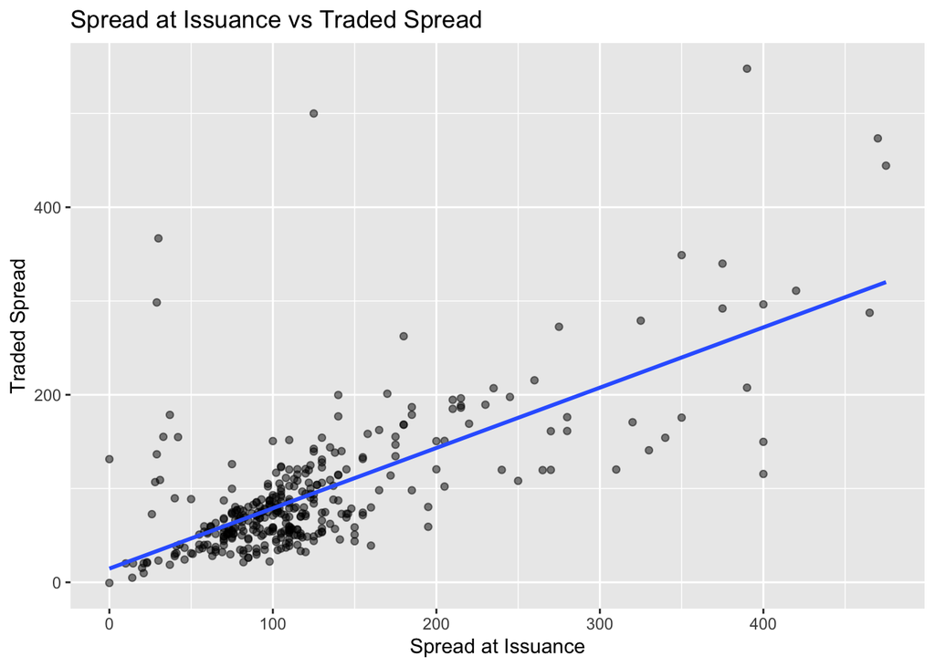

```r
static_data <- static_data %>%
  filter(!(id_isin %in% c('AU3FN0029096', 'AU0000017717', 'AU0000TTSHA8'))) #excluding the 3 isins

ggplot(static_data, aes(x = flt_spread, y = disc_mrgn_mid)) +
  geom_point(alpha = 0.5) +
  geom_smooth(method = "lm", se = FALSE) + # adding a trendline
  labs(title = "Spread at Issuance vs Traded Spread",
       x = "Spread at Issuance",
       y = "Traded Spread")
```

Looking at the plot, we can see the spreads more or less resemble a straight line, which is what we would theoretically expect. Bond issuers want to pay as little interest as possible, therefore we would expect them to price their bonds at a level that closely resembles the market conditions.

However, we notice that, on average, the traded spread appears to be slightly lower than the spread at issuance. This perhaps also makes sense, as bond issuers will want to make sure that their new issues are fully subscribed for and therefore might sell them just slightly below market price (similar to an IPO for equities).

### Mid trading margin over time

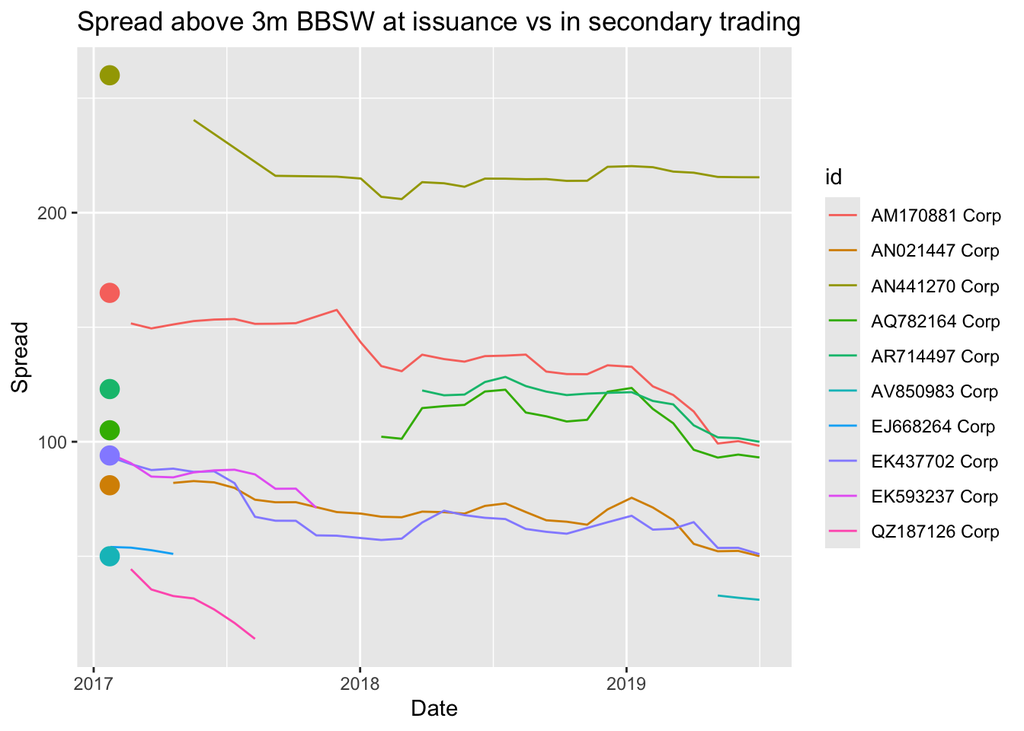

```r
set.seed(1) #reproducability
flt_spread_data <- static_data %>% select(c(id, flt_spread)) %>% mutate(date= as.Date(c("2017-01-23"))) # setting "2017-01-23" as the issue date for simplicity so looks nice on the plot
random_ids <- sample(unique(historic_data$id), 10) # taking 10 random issues to keep visibility

# Subset the data for the 10 randomly selected IDs
subset_historic_data <- historic_data[historic_data$id %in% random_ids, ]
subset_flt_spread_data <- flt_spread_data[flt_spread_data$id %in% random_ids, ]

p <- ggplot(subset_historic_data, aes(x = date)) +
  geom_line(aes(y = disc_mrgn_mid, color = id)) +
  labs(title = "Spread above 3m BBSW at issuance vs in secondary trading",
       x = "Date",
       y = "Spread")

p + geom_point(data = subset_flt_spread_data, size=4, aes(x = date, y = flt_spread, color = id), show.legend = FALSE)
```

This plot shows bonds’ spread above 3m BBSW at issuance (thick dots) compared to when traded in secondary markets. It appears that in most, though not all, case to confirm the earlier insight that, on average, spreads appear to decrease a little once a bond starts to trade in the secondary market. I will now look at this more quantitatively:

```r
flt_spread_data <- static_data %>% select(c(id, flt_spread))

summary_stats <- historic_data %>%
  group_by(id) %>%
  summarise(mean_spread = mean(disc_mrgn_mid), # calculating mean and sd for disc_mrgn_mid
            sd_spread = sd(disc_mrgn_mid))

spread_diff <- flt_spread_data %>%
  inner_join(summary_stats, by = "id") %>%
  mutate(diff_flt_mean_traded_spread = flt_spread - mean_spread) # calculating difference between spread at issuance and secondary trading

# Compute the largest difference between 'A' and 'flt' for each 'id'
largest_diff_flt_spread <- historic_data %>%
  inner_join(flt_spread_data, by = "id") %>%
  group_by(id) %>%
  summarise(largest_diff_spread = max(flt_spread - disc_mrgn_mid))
spread_diff %>% head()
```

```
##              id flt_spread mean_spread sd_spread diff_flt_mean_traded_spread
## 1 AF254428 Corp         90    59.05519 12.166316                    30.94481
## 2 AL104965 Corp         85    59.23419  9.602136                    25.76581
## 3 AL239800 Corp        110    81.13038 14.264693                    28.86962
## 4 AL317523 Corp        100    83.96915  8.376708                    16.03085
## 5 AL457315 Corp        112    88.63528 12.966292                    23.36472
## 6 AL516700 Corp        280   177.67030 26.120514                   102.32970
```

```r
largest_diff_flt_spread %>% head()
```

```
## # A tibble: 6 × 2
##   id            largest_diff_spread
##   <chr>                       <dbl>
## 1 AF254428 Corp                54.1
## 2 AL104965 Corp                38.1
## 3 AL239800 Corp                57.6
## 4 AL317523 Corp                29.2
## 5 AL457315 Corp                55.5
## 6 AL516700 Corp               127.
```

```r
mean_diff_flt_mean <- mean(spread_diff$diff_flt_mean_traded_spread, na.rm = TRUE)
mean_largest_diff <- mean(largest_diff_flt_spread$largest_diff_spread, na.rm = TRUE)
paste("Average difference between traded spread and issue spread:", mean_diff_flt_mean)
```

```
## [1] "Average difference between traded spread and issue spread: 15.2058961509817"
```

```r
paste("Average largest difference traded spread and issue spread:", mean_largest_diff)
```

```
## [1] "Average largest difference traded spread and issue spread: 35.8152212885154"
```

The above results indicate that, on average, the mean traded spread is 15 bps below the spread at issuance for all bonds. The average largest difference recorded in the data set between spread at issuance and traded spreads is quite a bit higher, at 36bps. This indicates that buying bond directly at issuance and speculating on a fall in spreads once bonds start being traded in secondary markets appears to be a profitable strategy, on average.

Metrics such as the above (e.g. mean traded spread, sd of traded spread, average difference between traded spread and issue spread) could be calculated for each bond issuer or each type of bond and included as features into the models. I will leave this to a later stage for now.

### Creating numerical credit ranking variable

Converting the credit rating variables into numerical variables so the model understands their relative ranking:

```r
table(static_data$rtg_sp)
```

```
##
##      A     A-  A- *-    A-1   A-1+     A+     AA    AA- AA- *-    AA+    AAA
##     32     28      7      1      1     35     10     73      1     10      2
##     B+    BB+    BBB BBB *-   BBB-   BBB+     NR
##      1      1     31      2      9     38      2
```

```r
table(static_data$rtg_sp_lt_fc_issuer_credit)
```

```
##
##      A     A-  A- *-     A+     AA    AA- AA- *-    AA+    AAA    BBB   BBB-
##     14     26      8     33      8     79      1     10      2     24      1
##   BBB+     NR
##     39      7
```

```r
table(static_data$rtg_sp_lt_lc_issuer_credit)
```

```
##
##      A     A-  A- *-     A+     AA    AA- AA- *-    AA+    AAA    BBB   BBB-
##     17     26      8     36      1     79      1     10      2     28      1
##   BBB+     NR
##     39      7
```

```r
table(static_data$rtg_fitch)
```

```
##
##       A      A-      A+      AA     AA-  AA- *-    AA-u     AAA     BBB    BBB-
##      20      20      30       3      59       1       2      13       3       4
##    BBB+ BBB+ *-    BBBu      WD
##       7       1       1       6
```

```r
table(static_data$rtg_moody)
```

```
##
##    A1    A2 A2 *-    A3   Aa1   Aa2   Aa3   Aaa   Ba1  Baa1  Baa2  Baa3    NR
##    30    20     6    26    22    23    73    16     4    37     5     8     9
##   P-1    WR
##     1     1
```

Some of these ratings look a bit suspect. For example, “A- * -”, “AA- * -”, “P-1” and “BBB*-“appear to be errors. Looking at the official S&Ps ratings, these are not official ratings of S&Ps. Instead, I suspect they are meant to be A-, AA- and BBB-, respectively. I will re-categorise them accordingly and change them to a numerical score to ease computation. Giovanni Ferri’s approach to this seems like a good idea that I will follow: https://www.researchgate.net/figure/Moodys-and-S-P-alphanumeric-ratings-conversion-into-numeric-values_tbl1_23722339

```r
# Define a function to convert credit ratings to numerical values
convert_rating_to_numeric <- function(credit_rating) {
  numerical_rtg <- case_when(
    credit_rating %in% c("AAA", "Aaa") ~ 100,
    credit_rating %in% c("AA+","Aa1") ~ 95,
    credit_rating %in% c("AA", 'Aa2') ~ 90,
    credit_rating %in% c("AA-", 'AA- *-', "AA-u", 'Aa3') ~ 85,
    credit_rating %in% c("A+", "A1") ~ 80,
    credit_rating %in% c("A", "A2", "A2 *-") ~ 75,
    credit_rating %in% c("A-", 'A- *-', "A-1+", "A-1", 'A3') ~ 70,
    credit_rating %in% c("BBB+", "BBB+ *-", "Baa1") ~ 65,
    credit_rating %in% c("BBB", "BBBu", "BBB *-", "Baa2") ~ 60,
    credit_rating %in% c("BBB-", "Baa3") ~ 55,
    credit_rating %in% c("BB+", "Ba1") ~ 50,
    credit_rating %in% c("BB", "Ba2") ~ 45,
    credit_rating %in% c("BB-", "Ba3") ~ 40,
    credit_rating %in% c("B+", "B1") ~ 35,
    TRUE ~ NA_real_  # set everything else as NA
  )
  return(numerical_rtg)
}

#applying the new function to the different ratings
static_data <- static_data %>%
  mutate(rtg_sp_num = convert_rating_to_numeric(rtg_sp),
         rtg_fitch_num = convert_rating_to_numeric(rtg_fitch),
         rtg_moody_num = convert_rating_to_numeric(rtg_moody),
         rtg_sp_lt_lc_issuer_credit_num = convert_rating_to_numeric(rtg_sp_lt_lc_issuer_credit),
         rtg_sp_lt_fc_issuer_credit_num = convert_rating_to_numeric(rtg_sp_lt_fc_issuer_credit)) %>%
  mutate(avg_num_rtg = rowMeans(select(., c("rtg_sp_num", "rtg_fitch_num", "rtg_moody_num", "rtg_sp_lt_lc_issuer_credit_num",  # creating average score
       "rtg_sp_lt_fc_issuer_credit_num")), na.rm = TRUE)) %>%
  select(-c(rtg_sp, rtg_fitch, rtg_moody, rtg_sp_lt_lc_issuer_credit, rtg_sp_lt_fc_issuer_credit)) # removing factor ratings scores

static_data$cpn_freq <- as.factor(static_data$cpn_freq) #coupon frequency needs to be interpreted as a factor and not a number to make sense
```

The above converts the categorical ratings into numerical ratings. Avg_num_rtg averages all 5 numerical ratings into 1 score. If there is no rating, it will be set to NA. This should help with reducing the amount of missing variables. These are generally excluded in a linear model, so we want to try reduce the amount of columns with NAs.

```r
sum(is.na(static_data$avg_num_rtg))
```

```
## [1] 16
```

### Model Selection

Overall, this problem looks like a relatively straight-forward regression problem, we have a number of categorical and numerical variables and a numerical response variable (FV). As a start, I will fit a simple linear regression model with variables that I would intuitively think are important here. I will then use a more automated model selection process to compare.

### Preparing the data set/ splitting into train-test sets

```r
static_data_reduced <- static_data %>% select(-c(rtg_sp_num, rtg_fitch_num, rtg_moody_num, rtg_sp_lt_lc_issuer_credit_num, rtg_sp_lt_fc_issuer_credit_num, bond_to_eqy_ticker, id, id_isin, issuer, security_name, basel_iii_designation, first_call_dt_issuance, bail_in_bond_designation)) %>% na.omit() # removing features that would not make sense (e.g names, isins) and ones with too much missing data to be useful (basel_iii, first_call_dt_issuance).

index <- sample(nrow(static_data_reduced), size = 0.8 * nrow(static_data_reduced)) # splitting the data into 80% training, 20% test set so we have an out-of-sample set to get a realistic estimate of model performance later on

# Split the data into train and test sets
static_data_train <- static_data_reduced[index, ]
static_data_test <- static_data_reduced[-index, ]
y_train <- static_data_reduced$disc_mrgn_mid[index]
y_test <- static_data_reduced$disc_mrgn_mid[-index]
```

### Linear Regression Model

```r
X <- static_data_train %>% select(-c( cntry_issue_iso, cntry_of_domicile, exch_code, bics_level_1_sector_name, bics_level_2_industry_group_name, amt_issued, amt_outstanding, reset_idx, step_up_down_provision, is_cd, is_covered, int_acc)) # using features that I would intuitively think make sense for an initial model

model <- lm(disc_mrgn_mid~.,data=X)
summary(model)
```

```
##
## Call:
## lm(formula = disc_mrgn_mid ~ ., data = X)
##
## Residuals:
##      Min       1Q   Median       3Q      Max
## -100.041  -12.865   -0.786   10.691  159.824
##
## Coefficients: (1 not defined because of singularities)
##                                Estimate Std. Error t value Pr(>|t|)
## (Intercept)                  -57.602134  52.179697  -1.104 0.270673
## flt_spread                     0.198803   0.049732   3.998 8.39e-05 ***
## final_maturity                 0.011024   0.002241   4.920 1.56e-06 ***
## issue_dt                       0.006094   0.002698   2.259 0.024761 *
## is_kangarooTRUE               12.143468   4.781978   2.539 0.011701 *
## is_subordinatedTRUE          -64.263157  17.643425  -3.642 0.000327 ***
## payment_rankJr Subordinated  -98.392148  46.945001  -2.096 0.037081 *
## payment_rankSecured          -62.495849  16.450622  -3.799 0.000182 ***
## payment_rankSr Non Preferred  -8.889996  25.539915  -0.348 0.728067
## payment_rankSr Preferred     -53.680317  16.708430  -3.213 0.001484 **
## payment_rankSr Unsecured     -67.174905  15.111021  -4.445 1.31e-05 ***
## payment_rankSubordinated             NA         NA      NA       NA
## cpn_freq12                     6.270286  28.591630   0.219 0.826589
## mty_typCALLABLE               20.718124   8.310976   2.493 0.013309 *
## avg_num_rtg                   -1.807075   0.230604  -7.836 1.27e-13 ***
## ---
## Signif. codes:  0 '***' 0.001 '**' 0.01 '*' 0.05 '.' 0.1 ' ' 1
##
## Residual standard error: 28.19 on 254 degrees of freedom
## Multiple R-squared:  0.7181, Adjusted R-squared:  0.7036
## F-statistic: 49.76 on 13 and 254 DF,  p-value: < 2.2e-16
```

This looks promising. Most variables appear to be highly statistically significant, in particular flt_spread and avg_num_rtg as expected. I will now go through a more systematic variable selection process. To ensure an unbiased estimate of which explanatory variables to include the best model, comparing all possible models through cross-validation is generally the best solution. Due to the large number of possible variables, a penalty driven variable selection process using AIC or Lasso regression seems like the most feasible option. This helps mitigate overfitting as it will penalise including more variables into the model.

### Lasso Regression Model

However, even Lasso is not a perfect way of selecting features. Therefore, I am going to exclude ones that either I know for sure are not going to be useful such as id, names etc that have no predictive information in them, or ones that have too many missing data points to be useful such as basel_iii_designation, first_call_dt_issuance and bail_in_bond_designation.

```r
X_train <- static_data_train %>% select(-disc_mrgn_mid) %>% data.matrix() #data needs to be in matrix form for lasso, xgb

#k-fold cross-validation to find optimal lambda value
cv_model <- cv.glmnet(X_train, y_train, alpha = 1)

#find optimal lambda penalty value that minimizes test MSE
best_lambda <- cv_model$lambda.min
paste("Best lambda: ", best_lambda)
```

```
## [1] "Best lambda:  4.66283913618237"
```

```r
paste("Lowest train RMSE: ", sqrt(min(cv_model$cvm)))
```

```
## [1] "Lowest train RMSE:  33.0442349214063"
```

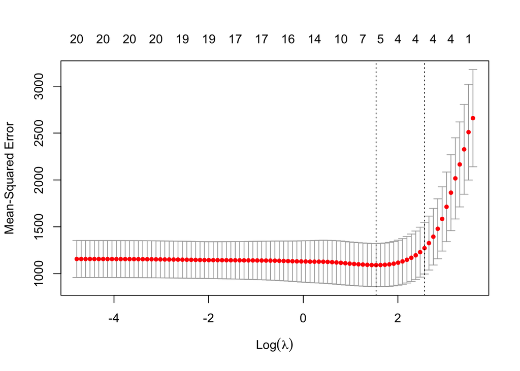

```r
#produce plot of test MSE by lambda value
plot(cv_model)
```

```r
best_model_lasso <- glmnet(X_train, y_train, alpha = 1, lambda = best_lambda)
coef(best_model_lasso)
```

```
## 22 x 1 sparse Matrix of class "dgCMatrix"
##                                             s0
## (Intercept)                       2.690035e+01
## flt_spread                        1.809062e-01
## final_maturity                    6.766258e-03
## issue_dt                          .
## amt_issued                       -1.565157e-09
## cntry_issue_iso                   .
## cntry_of_domicile                 .
## is_kangaroo                       .
## is_subordinated                   .
## payment_rank                     -1.977461e-01
## is_covered                        .
## exch_code                         .
## cpn_freq                          .
## reset_idx                         .
## mty_typ                           2.240504e+01
## is_cd                             .
## step_up_down_provision            .
## bics_level_1_sector_name          .
## bics_level_2_industry_group_name  .
## amt_outstanding                   .
## int_acc                           .
## avg_num_rtg                      -1.530140e+00
```

### Xgboost based Model

Doing a brief cross-validated grid search to identify the best training hyperparameters.

```r
# Define the parameter grid for XGBoost
param_grid <- expand.grid(
  nrounds = c(10, 50),      # Number of boosting rounds
  eta = c(0.01, 0.1, 0.2, 0.5),         # Learning rate
  max_depth = c(2, 4, 6),        # Maximum depth of trees
  min_child_weight = c(1, 3),
  gamma = c(0.1, 0.3, 0.5),
  colsample_bytree = 1,
  subsample = 1
)

# Set up cross-validation method
cv <- trainControl(
  method = "cv",              # k-fold cross-validation
  number = 10
)

xgb_grid <- train( # grid search
  X_train, y_train,
  method = "xgbTree",
  trControl = cv,
  tuneGrid = param_grid,
  metric = "RMSE",
  verbose = FALSE,
  verbosity = 0
)

xgb_grid$results[order(xgb_grid$results$RMSE),] %>% head()
```

```
##     eta max_depth gamma colsample_bytree min_child_weight subsample nrounds
## 112 0.5         2   0.1                1                3         1      50
## 116 0.5         2   0.3                1                3         1      50
## 120 0.5         2   0.5                1                3         1      50
## 144 0.5         6   0.5                1                3         1      50
## 140 0.5         6   0.3                1                3         1      50
## 136 0.5         6   0.1                1                3         1      50
##         RMSE  Rsquared      MAE   RMSESD RsquaredSD    MAESD
## 112 23.66642 0.8333968 14.87001 9.260433 0.05223120 4.430967
## 116 23.66642 0.8333968 14.87001 9.260433 0.05223120 4.430967
## 120 23.66642 0.8333968 14.87001 9.260433 0.05223120 4.430967
## 144 24.24995 0.8290641 14.81339 8.723242 0.04392151 4.133187
## 140 24.28732 0.8288885 14.84615 8.703330 0.04537209 4.148011
## 136 24.31059 0.8283885 14.83748 8.741530 0.04557702 4.110272
```

### Feature importance for Xgboost model

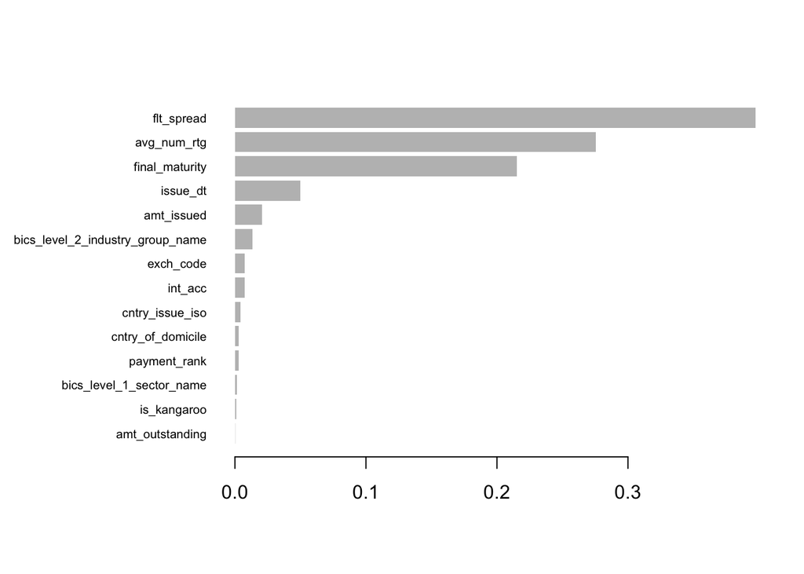

```r
best_model_xgb <- xgboost(data = X_train, label = y_train, max.depth = 2, eta = 0.5, gamma = 0.1, nrounds = 50, min_child_weight = 3, objective = "reg:squarederror", verbose=0)
importance_matrix <- xgb.importance(model = best_model_xgb)
xgb.plot.importance(importance_matrix = importance_matrix)
```

I will now fit one more linear model using the variables indicated as important by both Lasso and Xgboost, just as a baseline comparison to these two more sophisticated model. I will then compare all three on the out-of-sample test to get an indication of real-world performance.

### Final LM

```r
X <- static_data_train %>% select(c(flt_spread, final_maturity, avg_num_rtg, mty_typ, issue_dt, amt_issued, is_subordinated, payment_rank, disc_mrgn_mid))

best_model_lm <- lm(disc_mrgn_mid~.,data=X)
summary(best_model_lm)
```

```
##
## Call:
## lm(formula = disc_mrgn_mid ~ ., data = X)
##
## Residuals:
##      Min       1Q   Median       3Q      Max
## -103.801  -13.490   -1.456   11.499  158.312
##
## Coefficients: (1 not defined because of singularities)
##                                Estimate Std. Error t value Pr(>|t|)
## (Intercept)                  -7.448e+01  5.287e+01  -1.409 0.160143
## flt_spread                    2.167e-01  4.965e-02   4.364 1.86e-05 ***
## final_maturity                1.108e-02  2.254e-03   4.916 1.59e-06 ***
## avg_num_rtg                  -1.514e+00  2.615e-01  -5.788 2.08e-08 ***
## mty_typCALLABLE               2.120e+01  8.351e+00   2.539 0.011703 *
## issue_dt                      5.857e-03  2.711e-03   2.161 0.031658 *
## amt_issued                   -5.140e-09  3.164e-09  -1.625 0.105440
## is_subordinatedTRUE          -6.643e+01  1.771e+01  -3.751 0.000218 ***
## payment_rankJr Subordinated  -9.960e+01  4.716e+01  -2.112 0.035675 *
## payment_rankSecured          -6.183e+01  1.651e+01  -3.745 0.000223 ***
## payment_rankSr Non Preferred -1.165e+01  2.566e+01  -0.454 0.650286
## payment_rankSr Preferred     -5.462e+01  1.681e+01  -3.248 0.001317 **
## payment_rankSr Unsecured     -6.590e+01  1.518e+01  -4.341 2.05e-05 ***
## payment_rankSubordinated             NA         NA      NA       NA
## ---
## Signif. codes:  0 '***' 0.001 '**' 0.01 '*' 0.05 '.' 0.1 ' ' 1
##
## Residual standard error: 28.34 on 255 degrees of freedom
## Multiple R-squared:  0.7138, Adjusted R-squared:  0.7004
## F-statistic: 53.01 on 12 and 255 DF,  p-value: < 2.2e-16
```

### Comparing performance of the three models on the out-of-sample test set

```r
# Preparing the test set
X_test <- static_data_test %>% select(-disc_mrgn_mid) %>% data.matrix()
X_test_lm <- static_data_test %>% select(c(flt_spread, final_maturity, avg_num_rtg, mty_typ, issue_dt, amt_issued, is_subordinated, payment_rank))
# Make predictions
lm_preds <- predict(best_model_lm, X_test_lm)
lasso_preds <- predict(best_model_lasso, X_test)
xgb_preds <- predict(best_model_xgb, X_test)

lm_rmse <- RMSE(lm_preds, y_test)
lasso_rmse <- RMSE(lasso_preds, y_test)
xgb_rmse <- RMSE(xgb_preds, y_test)

paste("Linear Regression RMSE:", lm_rmse)
```

```
## [1] "Linear Regression RMSE: 32.9976722016702"
```

```r
paste("Lasso Regression RMSE:", lasso_rmse)
```

```
## [1] "Lasso Regression RMSE: 40.3466894463061"
```

```r
paste("XGBoost Regression RMSE:", xgb_rmse)
```

```
## [1] "XGBoost Regression RMSE: 27.0157788134918"
```

### Making predictions for the 2 newly issued bonds

I will now use the 3 models to make predictions for the FV spread for the newly issued bonds. Given that not all the information required is available in the description, I have used information from the other already issued bonds of the respective issuers to infer these missing data points. I would assume that things like credit ratings would not differ too much between different bonds from the same issuer. However, in a real-life scenario this would of course need to be checked specifically with the bond issuer.

```r
new_issues <- read_csv('new_issues_data.csv', show_col_types = FALSE) %>% select(-c(bond_to_eqy_ticker, id, issuer, basel_iii_designation, first_call_dt_issuance, bail_in_bond_designation)) # only keeping features we use in the model
new_issues$final_maturity <- as.Date(new_issues$final_maturity, format = "%d/%m/%Y")
new_issues$issue_dt <- as.Date(new_issues$issue_dt, format = "%d/%m/%Y")
new_issues
```

```
## # A tibble: 2 × 21
##   flt_spread final_maturity issue_dt   amt_issued cntry_issue_iso
##        <dbl> <date>         <date>          <dbl> <chr>
## 1         86 2024-07-03     2019-07-03  700000000 AU
## 2        105 2024-07-03     2019-07-03  600000000 CA
## # ℹ 16 more variables: cntry_of_domicile <chr>, is_kangaroo <lgl>,
## #   is_subordinated <lgl>, payment_rank <chr>, is_covered <lgl>,
## #   exch_code <chr>, cpn_freq <dbl>, reset_idx <chr>, mty_typ <chr>,
## #   is_cd <lgl>, step_up_down_provision <lgl>, bics_level_1_sector_name <chr>,
## #   bics_level_2_industry_group_name <chr>, amt_outstanding <dbl>,
## #   int_acc <dbl>, avg_num_rtg <dbl>
```

```r
lm_preds <- predict(best_model_lm, new_issues)
new_issues <- new_issues %>% data.matrix()
lasso_preds <- predict(best_model_lasso, new_issues)
xgb_preds <- predict(best_model_xgb, new_issues)
paste("LM pred: ", lm_preds, "Lasso pred: ", lasso_preds, "XGBoost pred: ", xgb_preds)
```

```
## [1] "LM pred:  72.4601271645918 Lasso pred:  68.2039693278427 XGBoost pred:  79.9840469360352"
## [2] "LM pred:  72.5497133718943 Lasso pred:  67.2072835962779 XGBoost pred:  80.4275054931641"
```

The three models indicate a FV spread range between 68 and 80bps above 3m BBSW for the ANZ bond, compared to spread at issuance of 86bps, and a FV spread range between 67 and 80bps above 3m BBSW for the TD bond, compared to spread at issuance of 105bps. This would indicate that both bonds are undervalued at issuance and we can expect a capital gain from purchasing them.

### Summary and potential improvements

Overall, I found the ‘flt_spread’, ‘final_maturity’, ‘avg_num_rtg’ (which is the combined numerical score based on all 5 credit rating variables), ‘mty_typ’ and ‘issue_amt’ features to be most useful in predicting disc_mrgn_mid, or the spread above 3m BBSW at which a bond traded. I used these to fit a multiple linear regression, a lasso regularised regression and a xgboost boosted tree regression classifier. All three models’ out-of-sample performance was roughly comparable, with the xgboost one slightly outperforming the lasso and linear regression one with a RMSE prediction error of 27 compared to 33 and 40 for linear regression and lasso regression, respectively.

I trained these models based on both static_data and snapshot_data, without using the historic spread data in historic_data. As mentioned before, this could be utilised to form additional features such as mean traded spread, sd of traded spread, average difference between traded spread and issue spread for each issuer or type of bond. It could also be used to infer traded spreads for bonds that have already matured, and thereby extended the dataset by another 200 observations or about 40%, which could increase model accuracy.

In addition to this, additional modelling approaches, such as other types of GLMs (Ridge, Elastic Net), other types of boosted trees/ random forests or linear regressions with interaction effects or non-linear transformations to features could have been fitted had there been more time. Overall, I am quite happy with the 3 models presented however.